# Limited consensus on what climate anxiety is: Insights from content overlap analysis on 12 questionnaires - ScienceDirect

## [Journal of Anxiety Disorders](https://www.sciencedirect.com/journal/journal-of-anxiety-disorders)

[Volume 109](https://www.sciencedirect.com/journal/journal-of-anxiety-disorders/vol/109/suppl/C), January 2025, 102957

# Limited consensus on what climate anxiety is: Insights from content overlap analysis on 12 questionnaires

https://doi.org/10.1016/j.janxdis.2024.102957[Get rights and content](https://s100.copyright.com/AppDispatchServlet?publisherName=ELS&contentID=S0887618524001336&orderBeanReset=true)

Under a Creative Commons [license](http://creativecommons.org/licenses/by/4.0/)

Open access

## Highlights

- •

  Uniformity of climate anxiety scales was examined using content overlap analysis.
- •

  With a systematic search, this study identified 12 distinct climate anxiety scales.
- •

  The 119 items covered a total of 57 disparate symptoms.
- •

  Mean and pairwise Jaccard Indices indicated a very weak item content overlap.
- •

  There is a critical need for consensus on the operationalization of climate anxiety.

## Abstract

Climate anxiety is a phenomenon that is gaining importance due to the general public’s increased awareness of the worsening climate crisis. At present, climate anxiety is not operationalized consistently across the existing literature. It is important to gain more consensus on the definition and operationalization of climate anxiety to facilitate reliable and generalizable research and to further develop interventions. Content analysis can contribute to this by providing insight into the overlap in the content of climate anxiety measures. With a systematic search, this study identified and analyzed 12 distinct scales measuring climate anxiety. The 119 items covered a total of 57 disparate symptoms. Jaccard indices showed that the mean overlap between symptoms of different climate anxiety scales was generally very low, as was the overlap between pairwise comparisons of climate anxiety scales. These results highlight the lack of uniformity in assessing climate anxiety and the need to properly define and operationalize this concept. The potential reasons for low overlap and how this might impact the reliability and validity of existing measures are discussed. It is critical that future work aims at finding consensus on the definition of climate anxiety (e.g., through a Delphi study) and psychometrically comparing the different questionnaires.

## Keywords

Climate anxiety

Environmental concern

Content analysis

Rating scales

Symptom overlap

Measurement

## 1. Introduction

Rising temperatures, extreme weather events, melting of ice caps, rising sea levels, increased pollution and biodiversity loss are all part of the current climate crisis induced by human activity (IPCC et al., 2022). According to recent reports, the future of many species is in danger, and humans will suffer as well from the effects of climate change if nothing changes in policy and behaviour (IPCC et al., 2022). Taking this into consideration, it is not surprising that some people worry about climate change or even experience certain levels of anxiety. Indeed, a global survey pointed out that 45.9 % of people were very or extremely worried and 28.2 % were very or extremely anxious as indicated on a 5-point [Likert scale](https://www.sciencedirect.com/topics/psychology/likert-scale) (i.e., indicated ≥ 4) when reporting their feelings regarding climate change (Ogunbode et al., 2022). For children and young people, these numbers are even higher with 59 % of children and young people globally being very or extremely worried and 84 % being at least moderately worried about climate change (Hickman et al., 2021). As such, the impact of climate change on [mental health](https://www.sciencedirect.com/topics/psychology/mental-health) has become more apparent and the term ‘climate anxiety’<sup>5</sup>; is gaining more attention in the public interest as well as in the scientific literature.

There are many definitions and operationalizations of climate anxiety (and/or eco-anxiety) that are currently used in the literature (Brophy et al., 2023, Cianconi et al., 2023, Coffey et al., 2021). One definition that is often used, is the one put forward by Clayton et al. (2017) in a report from the [American Psychological Association](https://www.sciencedirect.com/topics/psychology/american-psychological-association) (APA) which refers to climate anxiety broadly as “a chronic fear of environmental doom”. Other proposed definitions are mostly focused on feelings of worry, concern, distress and/or anxiety related to climate change (Albrecht, 2019, Clayton, 2020, Pihkala, 2020, Searle and Gow, 2010, Stanley et al., 2021). Moreover, climate anxiety is sometimes mentioned as a specific instance of several different eco-emotions (e.g. Albrecht, 2019), as a form of anxiety specifically focused on the changing climate (e.g., Clayton et al., 2017), as a continuum (Lutz et al., 2023), as a moral emotion (e.g., Kurth & Pihkala, 2022; Pihkala, 2020; Rozuel & Bellehumeur, 2022), and sometimes as a group-based emotion that is likely to be experienced if an individual identifies themselves to a certain social group (e.g., Harth, 2021). Additionally, there is an ongoing debate among scholars about the classification of climate anxiety, with some arguing against its medicalization by emphasizing that climate anxiety arises from a real and serious threat (e.g., Van Valkengoed, 2023). Taken together, currently it seems as if there is no consensus on what the concept of climate anxiety entails and what its defining components are. In line with this, scholars emphasize the lack of consensus regarding the conceptualization and measurement of climate anxiety, and underline the need for an integrative theoretical formulation of the construct (Heeren & Asmundson, 2023).

Constructs that are related to climate anxiety, and which are oftentimes used interchangeably (e.g., Stewart, 2021) or as a subcategory of climate anxiety, are eco-anxiety (e.g., Brophy et al., 2023), environmental concern (e.g., Strife, 2011) and climate worry (e.g., Stewart, 2021). Some scholars argue that these constructs can be seen as interconnected emotional responses of varying degrees to climate change and the consequences of this (Lutz et al., 2023). Eco-anxiety is broadly defined as a chronic fear of environmental doom, including a wide range of ecological issues beyond climate change alone (Albrecht, 2012, Clayton et al., 2017). Climate anxiety is a more specific term, referring to anxiety directly related to anthropogenic climate change (e.g., Hajek & König, 2022). Climate change distress, in turn, is referred to as negative affect related to climate change, including anxiety, sadness, guilt and anger (Hepp et al., 2023).

Environmental concern and climate worry are also discussed in the literature and are considered closely related to climate and eco-anxiety. Environmental concern, for example, appears to be strongly correlated to climate anxiety (Lutz et al., 2023). According to appraisal theories, concern, worry, and anxiety belong to the same family of internalizing emotions (e.g., Gross & Jazaieri, 2014; Moors et al., 2013; Snyder et al., 2023). Environmental concern represents an affective attitude toward environmental issues, reflecting an appraisal of the situation as potentially dangerous (e.g., Schultz et al., 2005; Strife, 2011; Yocco et al., 2015). Climate worry, on the other hand, can be seen as a psychological reaction to the appraisal of climate-related threats (Stewart, 2021), and likely serves the adaptive purpose of preparing for future disaster and/or finding possible solutions (e.g., Moors et al., 2013). Although appraisal theories of emotions can be a promising framework to conceptualize climate anxiety, worry and environmental concern (Van Valkengoed, Steg, et al., 2023), more research is needed to explore this further (Heeren & Asmundson, 2023).

The existing diversity of conceptualizations of climate anxiety and closely related constructs could lead to different ways of studying and operationalizing them. For example, when a definition is focused more on climate anxiety as a pathology, measurements could be more focused on impairment, whereas when a definition focuses more on the moral aspect of climate anxiety, measurements might be more focused on the direction of the emotion (i.e., of what and for whom is someone anxious/concerned). This lack of consensus in operationalizing climate anxiety is reflected in the proliferation of climate anxiety measures and questionnaires. For instance, for climate/eco-anxiety, measures include the Climate Change Anxiety Scale (CCAS; Clayton & Karazsia, 2020), the Hogg Eco-Anxiety Scale (HEAS-13; Hogg et al., 2021), the Eco-Anxiety Questionnaire (EAQ-22; Ágoston et al., 2022) and the climate anxiety subscale of the Inventory of Climate Emotions (ICE; Marczak et al., 2023). For climate change worry and distress, measures include the Climate Change Worry Scale (CCWS; Stewart, 2021), and the Climate Change Distress and Impairment Scale (CC-DIS; Hepp et al., 2023). This list only includes the validated measures that were identified in a review by Cianconi et al. (2023). Possibly, even more (un)validated scales that measure climate anxiety and related concepts have been developed.

Given the apparent lack of consensus on the operationalization and measurement of climate anxiety, it is important to examine what different climate anxiety questionnaires measure and if they measure the same construct (Heeren & Asmundson, 2023). This is important for future development and enhancement of climate anxiety scales, and to ensure generalizability of studies.

## 2. Method

### 2.1. Literature search and screening procedure

To identify all articles that include a measure of climate anxiety or related terms, a systematic search was conducted. Inclusion criteria were: (1) scales should be focused on climate anxiety, eco-anxiety, climate distress or worry, or environmental concern; (2) scales should include a standardizable scale; (3) scales should have been conducted by at least 3 studies when published more than 5 years before the date of the search; and (4) scales should be published and available in English. A literature search using PsychINFO and PubMed was conducted in November 2023, using the following keywords: ('climate anx*' OR 'climate fear' OR 'climate angst' OR 'climate worry' OR 'climate concern' OR 'climate distress' OR 'climate stress’ OR 'climate emotion*') OR ('eco anxiety' OR 'eco fear' OR 'eco angst' OR 'eco worry' OR 'eco concern' OR 'eco distress' OR 'eco stress' OR 'eco emotion*') OR ('eco-anxiety' OR 'eco-fear' OR 'eco-angst' OR 'eco-worry' OR 'eco-concern' OR 'eco-distress' OR 'eco-stress' OR 'eco-emotion*') OR ('global warming anx*' OR 'global warming fear' OR 'global warming angst' OR 'global warming worry' OR 'global warming concern' OR 'global warming distress' OR 'global warming stress’ OR 'global warming emotion*') OR ('environment* anx*' OR 'environment* fear' OR 'environment* angst' OR 'environment* worry' OR 'environment* concern' OR 'environment* distress' OR 'environment* stress’ OR 'environment* emotion*') NOT ('rat*' OR 'mouse' OR 'mice'). Titles as well as abstracts were screened based on these keywords.

Only English peer-reviewed journal articles that were published between 1980 and November 2023 were included, because climate change only became more known to the public in the 1980’s (e.g., with the establishment of the IPCC in 1988). The literature search was conducted using the PRISMA guidelines (Moher et al., 2010). A flow chart is shown in Fig. 1. Records from PsychINFO (*n* = 8753) and PubMed (*n* = 9456) were combined. In total, the search identified a total of 18209 records, of which 17651 remained after removal of duplicates (*n* = 558). Next, records were screened and evaluated on relevance (i.e., whether a paper included a quantifiable measurement of climate anxiety, eco-anxiety, or climate distress/concern/worry), by checking for relevant keywords, closely reading descriptions of the content of included scales, and inspecting the context of these studies. For this phase, an Artificial Intelligence (AI) tool named Active learning for [Systematic Reviews](https://www.sciencedirect.com/topics/psychology/systematic-review) (ASReview) was used (version v1.3.2; ASReview LAB developers, 2023). This software uses learning algorithms based on the input of the reviewer, resulting in an interactive process (Van De Schoot et al., 2021). The program ranks records by relevance so that the screening process takes less time (i.e., after the screening process of a certain number of records no new relevant records will turn up anymore). Simulations show that the ASReview software identifies 95 % of relevant articles after screening only 8–33 % of the total articles, and finds 70–100 % of relevant abstracts after reviewing just 10 %, highlighting its significant efficiency and time-saving benefits (Van De Schoot et al., 2021).

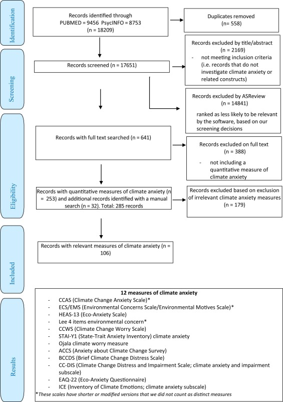

Fig. 1. Flow chart of systematic search to identify measures of climate anxiety.

Based on this first screening with the ASReview software, 2169 studies were excluded as they were qualitative or not related to climate anxiety or related terms, and 14841 were excluded as they were ranked as less likely to be relevant by the ASReview software. To reduce the risk of trap formation (i.e., ending up in a particular category of articles, meaning that other subcategories of articles are not found; Sijtsma et al., 2021), and to reduce user bias influencing model training (e.g., what is highlighted as relevant or irrelevant), the reviewing process was continued until 250 irrelevant articles in a row turned up, which exceeds recommendations (i.e., 100 irrelevant articles; Wagner et al., 2022). After that point, the screening process was terminated (specifically after screening *n* = 2810 records or 15.92 % of the total records). In the last 1100 articles, only 7 relevant articles had appeared. This is in line with simulations of active learning-based systematic reviewing, which indicate that after screening approximately 10 % of the records almost all relevant records would have been found (Teijema et al., 2023). Our screening, of 15.92 % of the total records, went thus beyond this threshold.

We checked whether the remaining 641 articles included a quantifiable measure of climate anxiety or related concepts. After exclusion, 253 articles remained (388 were excluded). Additionally, because the ASReview software is a relatively new tool, and because there is a small risk of trap formation when not all records have been screened, a manual search through Google Scholar and reference lists of included articles was conducted. This resulted in 32 additional articles. The remaining 285 articles were screened and all 76 quantifiable measures of climate anxiety or related concepts that were identified in these articles were summarized. These measures were all screened for relevance by two different reviewers, and excluded (after thorough discussion, to reach consensus) when they were not related enough to the concept of climate anxiety (i.e., measured environmental values/beliefs, hazard events, other constructs, or were not focused on emotions; *n* = 46), when they were referred to by only one or two studies (provided that the measure was older than 5 years; *n* = 17), or when the measure did not include a standardizable scale (*n* = 1). An overview of this is given in the Appendix (https://osf.io/tjcwz/). Questionnaires that were used only once or twice but were constructed within the past 5 years and, therefore, could not have been readily picked up from the literature yet, were also included. This final screening identified 12 different measures that were judged as relevant to include in the content overlap analysis (climate anxiety/eco-anxiety: *n* = 5, climate worry: *n* = 2, environmental concern: *n* = 2, climate distress: *n* = 2, eco-emotions with a subscale for climate anxiety: *n* = 1). See Fig. 1. These 12 measures were combinedly used in 106 studies. A list of these studies is available on the [Open Science](https://www.sciencedirect.com/topics/psychology/open-science) Framework (https://osf.io/tjcwz/).

Additional information about the 12 measures was extracted from the records, such as the internal reliability, whether and how often factor analysis was performed on the specific measure, what the outcomes were of the factor analysis in terms of factor structure, and whether there are translations of the measures. An overview of this can be found in Table 1.

| **Scale** | **Administered (****n****)**<sup>a</sup> | **Original source** | **Items (****n****)** | **Construct** | **Factor analysis done** | **Factor structure (n items)** | **Temporal focus**<sup>b</sup> | **Internal reliability (Cronbach’s alpha)** | **Available languages** |
| --- | --- | --- | --- | --- | --- | --- | --- | --- | --- |
| CCAS | 43 | Clayton & Karazsia, (2020) | 13 | Climate anxiety | Yes | Cognitive-emotional impairment (8), functional impairment (5) | Not specified | CEI:.78−.98, FI:.73−.94 Overall:.87−.97 | English, German, French, Italian, Norwegian, Polish, Korean, Spanish, Turkish, Chinese, Japanese |
| ECS/ EMS | 32 | Schultz, (2001) | 12 | Environmental concern | Yes | Biospheric (4), egoistic (4), altruistic (4) | Not specified | Biospheric:.73−.96 Egoistic:.71−.94 Altruistic:.61−.92 Overall:.92−.96 | English, Swedish, Dutch, German, Spanish, Greek, Turkish, Portuguese, Czech, Russian |
| HEAS−13 | 12 | Hogg et al., (2021) | 13 | Eco-anxiety | Yes | Affective symptoms (4), rumination (3), behavioural symptoms (3), anxiety about personal impact (3) | Past two weeks | AS:.83−.88 RU:.84−.89 BS:.71−.86 PI:.82−.91 Overall:.86−.94 | English, German, French, Turkish, Portuguese |
| Lee | 9 | Lee, (2008) | 4 | Environmental concern | Yes | One factor | Not specified | .77−.94 | English |
| CCWS | 4 | Stewart, (2021) | 10 | Climate worry | Yes | One factor | In general | .93−.98 | English, Italian |
| STAI-Y1 | 4 | Spielberger, (1983); Ogunbode et al., (2022) | 7 | Climate anxiety | No<sup>c</sup> | - | Right now | .89 .65−.92 (differing between countries) .72−.92 (differing between countries) | English |
| Ojala | 3 | Ojala, (2012) | 5 | Climate worry | Yes | Macro worry (3), micro worry (2) | Not specified | Macro:.88 Micro:.88 Overall:.89 | English, Swedish |
| ACCS | 1 | Klingler & Darner, (2020); Meixner et al., (2023) | 12 | Climate anxiety | No<sup>d</sup> | Climate Change Anxiety (9), Generalized Anxiety (3) | Not specified | - | English |
| BCCDS | 1 | Latkin et al., (2022) | 5 | Climate change distress | Yes | One factor | Not specified | .89 | English |
| CC-DIS<sup>e</sup> | 1 | Hepp et al., (2023) | 12 | Climate change distress | Yes | Climate Change Distress (15, including anger, sadness and anxiety) Climate Change Impairment (8). | Not specified | Coëficient omega = .914 for distress,.888 for impairment | English, German |
| EAQ−22 | 1 | Ágoston et al., (2022) | 22 | Eco-anxiety | Yes | Habitual ecological worry (13), Negative consequences of eco-anxiety (9) | Not specified | HEW subscale:.91; NCEA subscale:.86 | English, German<sup>f</sup> |
| ICE<sup>g</sup> | 1 | Marczak et al., (2023) | 4 | Climate anxiety | Yes | Climate anger (4), Climate contempt (4), Climate enthusiasm (4), Climate powerlessness (4), Climate guilt (4), Climate isolation (4), Climate anxiety (4), Climate sorrow (4) | Not specified | .86 for the climate anxiety subscale | English, Polish |

*Note*. Mentioned scales are the Climate Change Anxiety Scale (CCAS; Clayton & Karazsia, 2020), the Environmental Concerns Scale (ECS; also referred to as Environmental Motives Scale (EMS); Schultz, 2001) the Hogg Eco-Anxiety Scale (HEAS-13; Hogg et al., 2021), the Lee environmental concern measure (Lee, 2008), the Climate Change Worry Scale (CCWS; Stewart, 2021), the State-Trait Anxiety Inventory adjusted to climate change (STAI-Y1; Spielberger, 1983; Ogunbode et al., 2022), the Ojala climate worry measure (Ojala, 2012), the Anxiety about Climate Change Survey (ACCS; Klingler & Darner, 2020; Meixner et al., 2023), the Brief Climate Change Distress Scale (BCCDS; Latkin et al., 2022), the Climate Change Distress and Impairment Scale (CC-DIS; Hepp et al., 2023), the Eco-Anxiety Questionnaire (EAQ-22; Ágoston et al., 2022), and the climate anxiety subscale of the Inventory of Climate Emotions (ICE; Marczak et al., 2023).

**a**

’Administered’ refers to the number of publications within our search, out of 641 full-text screened articles, in which the scale is not only mentioned but also administered.

**b**

Highlights the specific time period the items are focused on.

**c**

Although the original STAI has been examined with factor analyses, the climate change version has not (yet). The number of citations of the STAI-Y1 (*n* = 4) is also referring to the climate change version.

**d**

The ACCS was originally published at a conference (Klingler & Darner, 2020). The scale was thus used in one publication (Meixner et al., 2023). Personal communication pointed out that a validation study of the ACCS is being worked on.

**e**

Complete CC-DIS consists of 23 items, only the anxiety questions of the Climate Change Distress subscale and the Climate Change Impairment subscale were included in the content overlap analysis.

**f**

A preprint is available with a German translation of the EAQ-22: https://doi.org/10.21203/rs.3.rs-3606150/v1

**g**

Complete ICE consists of 32 items, only the climate anxiety subscale was included in the content overlap analysis.

### 2.2. Outline of data analysis

To determine the overlap between climate anxiety questionnaires, we conducted a content overlap analysis (Fried, 2017, Gauld et al., 2023). This method has been used for various groups of [psychometric](https://www.sciencedirect.com/topics/psychology/psychometrics) instruments, such as instruments that measure sleeping disorders, major depression, neurological soft signs, (hypo)mania, obsessive-compulsive disorder, mental pain, and trauma exposure (e.g., Charvet et al., 2022; Chrobak et al., 2021; Chrobak et al., 2018; Fried, 2017; Gauld et al., 2023; Karstoft & Armour, 2023; Visontay et al., 2019). Additionally, previous research has applied this method to self-report measures of anxiety (Wall & Lee, 2022). The steps described below are based on previous studies using content overlap analysis.

First, a list of all items was made. One item normally corresponds with one question. However, some questions of some questionnaires have multiple sub-questions, and these were all counted as separate items. For example, the HEAS-13 (Hogg et al., 2021) contains a single question where 13 sub-questions must be answered, so 13 items were extracted from this questionnaire. In total, 119 items were extracted from the 12 questionnaires.

Table 2. Number of items and symptoms that appear across scales.

[output not shown]

*Note*. 33 of the 57 symptoms are only present in a single scale and none of the 57 symptoms appear across all 12 scales.

**a**

’Administered’ refers to the number of publications within our search, out of 641 full-text screened articles, in which the scale is not only mentioned but also administered.

Fourth, a Jaccard index was calculated to measure overlap (Fried, 2017, Gauld et al., 2023). This index can range from 0 (no overlap between questionnaires) to 1 (complete overlap) and is calculated by the equation s/(u1 + u2 + s), with ‘s’ as the number of symptoms that overlap between two questionnaires and ‘u1’ and ‘u2’ as the number of symptoms that do not overlap. The following classification was used for the interpretation of the indices (Evans, 1996): very weak: (0.00–0.19), weak: (0.20–0.39), moderate: (0.40–0.59), strong: (0.60–0.79), and very strong: (0.80–1). The mean overlap for all 12 questionnaires as well as the pairwise overlaps between each pair of scales was calculated. The content overlap between the questionnaires was visualized using the code from Fried (2017), as adapted by Wall and Lee (2022), using RStudio (R Core Team, 2021). The used datafiles and R code are available on the Open Science Framework (https://osf.io/tjcwz/).

## 3. Results

### 3.1. Descriptive results

With a systematic search, 12 scales measuring climate anxiety or related constructs were identified. All scales were published between 2001 and 2023 and ranged from 4 to 22 items, with a mean of 9.9 items. To determine the degree to which psychometric validation was done for each of the scales we identified, we looked at whether factor analysis (exploratory or confirmatory) was previously carried out. Ten of these scales were previously examined with a factor analysis in at least one of the citations, and two scales were not yet examined with a factor analysis at the date of the systematic search (i.e., the ACCS and the STAI-Y1). The most often administered scale was the CCAS (*n* = 43), followed by the ECS (*n* = 32), and the HEAS-13 (*n* = 12). See Table 1 for an overview of factor structures and reliability.

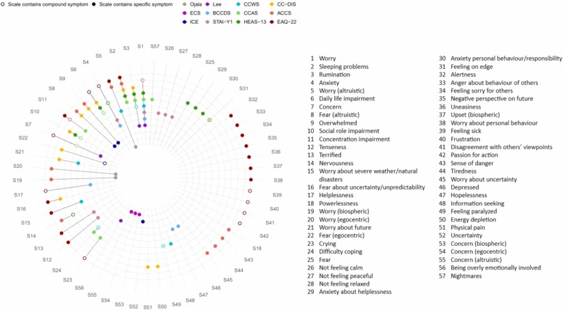

Fig. 2. Visualization of all symptoms across scales. *Note.* All colors represent different scales, all numbers represent different symptoms. Symptoms are ordered from most occurring symptoms to least occurring symptoms. A filled-in dot means that a scale contains this symptom in a specific item, and an empty dot means that a scale only contains this symptom in a compound item.

The number of symptoms per scale ranged from 3 to 23, with a mean of 8.5 symptoms per scale. The scale that covered the most symptoms was the EAQ-22 (*n* = 23, 40.4 % of all disparate symptoms), being the scale with the most items, followed by the ACCS (*n* = 13, 22.8 % of all disparate symptoms). The scales that covered the least symptoms were the ECS and the Ojala measure (both covered *n* = 3, 5.3 % of all disparate items).

Of all the 57 symptoms, 33 (57.9 %) were covered by only one scale, and 13 symptoms (22.8 %) were covered by two scales. Only 11 symptoms (19.3 %) were covered by 3 or more questionnaires. These 11 most featured symptoms were worry (covered by 7 scales), rumination (covered by 5 scales), sleeping problems (covered by 5 scales), worry (altruistic), anxiety and daily life impairment (all covered by 4 scales), and concern, feeling overwhelmed, fear (altruistic), social role impairment, and concentration impairment (all covered by 3 scales). On average, a symptom recurred in 1.8 measures. Of all 33 symptoms that only appeared in one measure, six were only featured as part of a compound item in the scale. See Fig. 2 for an overview of symptoms across scales.

### 3.2. Jaccard indices

Across all scales, the Jaccard index was 0.08, which shows that there is a very weak overlap between the scales. Overall, mean overlap for each individual scale with all other scales ranged between 0 and 0.13, indicating that overlap for each scale with all other scales was very low. The mean overlap was the highest (i.e., the most common symptoms with other scales) for the CCAS (0.13), the HEAS-13 (0.12), and the ACCS (0.11). However, these all qualify as very low overlap. The scales that had the fewest symptoms in common with other scales were the ECS (0), the Ojala measure (0.02), and the ICE (0.03). See Table 3 for all mean Jaccard indices.

Table 3. Mean Jaccard and pairwise Jaccard Indices per scale.

| Empty Cell | CCAS | ECS | HEAS-13 | Lee | CCWS | STAI-Y1 | Ojala | ACCS | BCCDS | CC-DIS | EAQ-22 | ICE |
| --- | --- | --- | --- | --- | --- | --- | --- | --- | --- | --- | --- | --- |
| CCAS | 1 |  |  |  |  |  |  |  |  |  |  |  |
| ECS | 0 | 1 |  |  |  |  |  |  |  |  |  |  |
| HEAS−13 | 0.31 | 0 | 1 |  |  |  |  |  |  |  |  |  |
| Lee | 0.27 | 0 | 0.15 | 1 |  |  |  |  |  |  |  |  |
| CCWS | 0.20 | 0 | 0.12 | 0.20 | 1 |  |  |  |  |  |  |  |
| STAI-Y1 | 0.06 | 0 | 0.13 | 0.10 | 0.07 | 1 |  |  |  |  |  |  |
| Ojala | 0 | 0 | 0 | 0 | 0 | 0 | 1 |  |  |  |  |  |
| ACCS | 0.15 | 0 | 0.14 | 0.06 | 0.11 | 0.05 | 0.23 | 1 |  |  |  |  |
| BCCDS | 0.07 | 0 | 0.14 | 0.13 | 0.08 | 0.20 | 0 | 0.06 | 1 |  |  |  |
| CC-DIS | 0.24 | 0 | 0.22 | 0.07 | 0.12 | 0 | 0 | 0.14 | 0 | 1 |  |  |
| EAQ−22 | 0.18 | 0 | 0.10 | 0.04 | 0.07 | 0.11 | 0.04 | 0.09 | 0.08 | 0.10 | 1 |  |
| ICE | 0 | 0 | 0 | 0 | 0 | 0 | 0 | 0.13 | 0 | 0.25 | 0 | 1 |
| Mean similarity | 0.13 | 0 | 0.12 | 0.09 | 0.10 | 0.07 | 0.02 | 0.11 | 0.07 | 0.10 | 0.07 | 0.03 |

*Note.* Jaccard Indices were calculated to measure overlap. This index can range from 0 (no overlap between questionnaires) to 1 (complete overlap) and is calculated by the equation s/(u1 + u2 + s), with ‘s’ as the number of symptoms that overlap between two questionnaires and ‘u1’ and ‘u2’ as the number of symptoms that do not overlap. The following classification was used for the interpretation of the indices: very weak: (0.00–0.19), weak: (0.20–0.39), moderate: (0.40–0.59), strong: (0.60–0.79), and very strong: (0.80–1) (Evans, 1996).

For the pairwise indices, the four pairs of scales with the highest pairwise Jaccard Index still indicated only a ‘weak’ overlap. The overlap between the CCAS and the HEAS-13 was the highest, with a Jaccard index of 0.31. After this, the overlap between the CCAS and Lee measure (0.27), the CC-DIS and the ICE (0.25), and CCAS and the CC-DIS (0.24) had the most overlap, even though the indices for these four pairs of scales are still considered as ‘weak’ overlap. For 28 of the 66 pairs (42.4 %) there was no overlap between the two scales whatsoever. The ECS had no overlap with any of the 11 other scales, the ICE and the Ojala measure had no overlap with 9 of the other scales, the CC-DIS, the STAI-Y7, and the BCCDS had no overlap with 4 other scales, and the Lee measure, The CCWS, the CCAS, and the HEAS-13 had no overlap with 3 other scales. The scales that overlapped with the most other scales were the ACCS (overlapped with all scales, except for the ECS), and the EAQ-22 (overlapped with all scales, except for the ECS and the ICE). However, even when there was overlap between scales, this was still weak to very weak. For all pairwise Jaccard indices, see Table 3.

## 4. Discussion

At present, climate anxiety is not operationalized consistently across the existing literature. It is therefore important to gain more consensus on the definition and operationalization of climate anxiety to facilitate reliable and generalizable research. To gain more insight into overlap in content of climate anxiety measures, we conducted a content overlap analysis. With a systematic search, we identified, included, and analyzed 12 distinct scales measuring climate anxiety. The 119 items covered a total of 57 disparate symptoms. The mean Jaccard Index of 0.08 indicated a very weak item content overlap between all the scales, meaning that the symptoms captured by the items were very heterogenous. Furthermore, not only was item content overlap very weak, but 57.9 % of all symptoms were only featured in one scale, showing that scales included many unique items. Finally, pairwise overlaps between pairs of scales were all considered ‘weak’ or ‘very weak’ indicating that all the scales had little overlap with one another, even those that specifically measured climate anxiety (rather than climate worry or environmental concern). Overall, these results show that there is lack of uniformity in assessing climate anxiety.

The lack of overlap between measures of climate anxiety may be due to different reasons. One possible reason for the lack of overlap is that there is currently no agreed-on definition of climate anxiety, thus the heterogeneity of scales could stem from the diversity of definitions being used in the literature. This differs from concepts such as depression or sleep problems, for which there are more formalized definitions (e.g., DSM-5 criteria for depression). In addition to this, operationalizations of the various definitions may place more emphasis on adaptive versus maladaptive anxiety, on the direction of the anxiety (e.g., egoistic, altruistic, and biospheric), or on the behavioral consequences of anxiety. This conceptual heterogeneity is likely due to climate anxiety being a relatively new concept in the literature (e.g., Heeren & Asmundson, 2023), with most of the measures only being introduced in the literature in the last 5 years.

In the current state of the literature, definitions of climate might be either too broad or too susceptible for different interpretations, resulting in diversity in operationalizations. Summarizing the 11 most represented symptoms identified in this study, climate anxiety could be defined as overwhelming feelings of anxiety, concern, worry and fear (possibly focused on other people) surrounding the climate crisis, co-occurring with rumination and/or concentration impairment, resulting in sleeping problems and/or impairment in daily and social life. However, there is a need for a more overarching and integrating framework for assessing climate anxiety (Heeren & Asmundson, 2023). Van Valkengoed, Steg, et al. (2023) identified emotional, physiological, cognitive, and behavioural indicators of climate anxiety (see also: Lang, 1968, Lang, 1979). These four domains are all represented in the 11 most featured symptoms. However, when inspecting all 57 disparate symptoms, emotional indicators are highly represented, whereas behavioural, cognitive, and physiological indicators are scarcely covered. The proportionally high representation of emotional indicators is in line with most definitions of climate anxiety, indicating that the concept is approached as a mainly emotional phenomenon. However, for a full assessment of climate anxiety, behavioural, cognitive, and physiological indicators may require more consideration.

One possible factor contributing to the lack of consensus on the definition and operationalization of climate anxiety could be that it is not currently used as a clinical diagnosis. Comparing the current findings with findings from other studies examining scales measuring DSM-5 diagnoses (e.g., depression, anxiety), climate anxiety measures seem to have less overlap than these DSM-5 disorder-based scales. However, even for depression and anxiety questionnaires content overlap in existing scales is weak (e.g., Fried, 2017; Wall & Lee, 2022). In contrast, scales measuring DSM-5 diagnoses that are more specific in diagnostic criteria show higher overlap (e.g., sleeping disorders; Gauld et al., 2023). Thus, it seems that the more the DSM-5 already distinguishes a definition and accompanying symptoms, scales have a more set direction for what the items should measure and thus more overlap. If climate anxiety were to become a disorder in future editions of the DSM with its own diagnostic criteria, this may potentially aid (somewhat) in the harmonization of questionnaires. Nonetheless, we do not necessarily recommend including climate anxiety into the DSM, because climate change is a realistic concern and pathologizing might not be useful (Van Valkengoed, 2023). Additionally, facilitating very specific diagnostic criteria of climate anxiety might not be the solution for the harmonization of scales, since climate anxiety might simply be a broader concept than for example sleeping disorders. Still, if specifying criteria is not the solution, other ways to increase the overlap of climate anxiety scales should be considered.

Another potential explanation for the low overlap between the included scales could be that they are addressing slightly different emotions (climate anxiety, worry, and concern). Our decision to directly compare these questionnaires stems from the high overlap between anxiety, worry, and concern in some emotion theories (e.g., Snyder et al., 2023) and the association of concern and worry with anxiety in appraisal theories of emotions (e.g., Gross & Jazaieri, 2014; Moors et al., 2013). Our findings indicate that the ECS (measuring environmental concern) and the Ojala measure (measuring worry) exhibit the lowest overlap with other scales. However, even questionnaires specifically focused on climate anxiety show limited content overlap. Notably, the pair with the highest mean overlap, the CCAS and the HEAS-13 (both focused on climate anxiety), are scored as 'weak' on content overlap. Thus, even scales that both measure climate anxiety may show very little overlap. This suggests that the lack of overlap is not solely due to the inclusion of climate anxiety, worry, and concern.

One approach to better understand the lack of content overlap between measures of climate anxiety, worry, concern, and distress, is to map these constructs along a continuum of climate anxiety. This continuum could be understood through the appraisal theory, where individuals assess the threat of climate change differently, possibly leading to varied emotional responses depending on how they evaluate the graveness and controllability of the threat. This continuum could imply that different measures of climate anxiety and environmental concern capture varying intensities or aspects of the overall spectrum of climate-related emotional responses (e.g., Lutz et al., 2023). In other words, the diversity of the content of the measures might reflect a range of experiences along a spectrum rather than it being an indication that the constructs are unrelated or too distinct. Further (empirical) research is needed to shed more light on this suggestion, particularly by examining how different appraisals influence where individuals fall on this continuum. This should be considered when constructing scales for climate anxiety, because overlooking a continuum when designing a scale could be problematic for its measurement properties, such as its ability to discriminate between individuals on the extreme high or low end of climate anxiety (Tay & Jebb, 2018).

Finally, a last important reason for the low overlap could be the variety in aim and focus of scales. For example, the ECS and Ojala measures ask about concern and worry aimed at the subjects’ own safety (egocentric), that of other people and loved ones (altruistic), and of the natural environment (biospheric). Although concern and worry are prevalent symptoms in other scales, the direction of this worry is not always specified. This may be the result of the scales being designed for different purposes. For example, where the ECS and the Ojala measure are more aimed at identifying the focus of the climate concern or worry, the CCAS and the CC-DIS are more focused on assessing impairment. A study by Lutz and colleagues (2023) argues that the CCAS does not capture the emotional aspect of climate anxiety but instead is focused on the more severe cases of the climate anxiety spectrum since both subscales of the CCAS are solely focused on impairment (cognitive-emotional impairment and functional impairment). In line with this, Wullenkord et al. (2021) argue that the CCAS only captures impairment as a consequence of the climate crisis but does not capture the full range of emotional experience (e.g., mild concern). Thus, apart from the lack of a theoretical framework and consensus in the definition of climate anxiety, the reason for the low overlap between the different scales is likely the result of the variety in aim and focus of scales (e.g., identifying the direction of the concern or assessing impairment).

While the low content overlap between scales has been noted, it is important to consider whether this actually affects their ability to measure the same construct. Limited content overlap may be an issue at face value but may not be a major issue in the psychometric sense. Different questionnaires may psychometrically measure the same underlying construct and show high [convergent validity](https://www.sciencedirect.com/topics/psychology/convergent-validity) according to latent variable models (e.g., Watson et al., 1995), yet low overlap between scales does not necessarily mean that they measure different constructs. Instead, it could reflect different manifestations of climate anxiety across different contexts. While the specific content of climate anxiety symptoms may vary based on individual experiences or local issues, it is possible that the underlying nature of these symptoms remains consistent. For example, acoustic and auditory [hallucinations](https://www.sciencedirect.com/topics/psychology/hallucination) differ in content, but are both still forms of hallucinations. Similarly, it could be that worry about the impacts of climate change on yourself (coded as worry egocentric), and on others (coded as worry altruistic), differ in content, but are both still forms of worry. However, this cannot be decisively established with content overlap analysis alone. Future research using psychometric analyses such as factor analyses across the different climate anxiety questionnaires can shed more light on whether the questionnaires measure the same construct. We recommend that scales specify the content of worry, anxiety, or concern to avoid ambiguity and reduce variability in responses, as the wording, format, and context of questions could impact how respondents interpret and answer them (Schwarz, 1999).

Based on the results of our content analysis, we see several important directions for future research. First, an empirical comparison of climate anxiety scales using factor analysis can give more insight into the latent structure, performances, and biases of the scales. Particularly, factor analysis could reveal that different scales measure the same latent construct, despite using different items. Such an empirical comparison can be relevant to provide a more data-driven comparison of the content of the scales. This can be useful to develop a reliable and generalizable climate anxiety scale.

Furthermore, the heterogeneity in the definition of climate anxiety should be considered in future research. The finding that different scales have different focuses and purposes does not have to be problematic for specific research questions and studies but could still result in low generalizability of results. This study shows that there currently is no agreement on an operationalization of climate anxiety and that a scale that measures an overarching set of climate anxiety symptoms is still lacking. However, this does not mean that scales are underdeveloped or not worth using. Specific scales can have different purposes and can therefore have their own merit within a particular context. More clarity on the construct allows for the development of robust theoretical models that can explain how climate anxiety manifests and elaborate on potential triggers, protective factors, and potential consequences (e.g., Heeren & Asmundson, 2023). Therefore, and given its status as an emerging field, it is important to find more consensus on the definition and assessment of climate anxiety, considering the different components of anxiety (i.e., emotional, physiological, cognitive, and behavioural), different directions (i.e., egocentric, altruistic, and biospheric), and different purposes (i.e., full range of climate anxiety or focus on impairment). This may be achieved by bringing together a panel of experts and stakeholders to reach consensus on a definition and assessment techniques, for example using the Delphi method.

In conclusion, with this study we intended to examine the content overlap among climate anxiety scales. Overall, this study not only shows that there is remarkably low overall overlap between these scales but also a consistently low pairwise overlap and thus heterogeneity in the concept of climate anxiety. This stresses the need to properly define and operationalize the concept of climate anxiety in future work. This includes psychometrically comparing the different questionnaires using factor analyses and finding consensus in the definition of climate anxiety (e.g., through a Delphi study). This content analysis gives direction to this future work by outlining the current available scales and the different dimensions to consider in assessment.

## CRediT authorship contribution statement

**Silke van Dijk:** Writing – original draft, Visualization, Investigation, Formal analysis, Conceptualization. **Kevin van Schie:** Writing – review & editing, Supervision, Conceptualization. **Tom Smeets:** Writing – review & editing, Supervision. **Gaëtan Mertens:** Writing – review & editing, Supervision, Methodology, Investigation, Conceptualization.

## Declaration of Competing Interest

The authors declare that they have no known competing financial interests or personal relationships that could have appeared to influence the work reported in this paper.

## Acknowledgements

This research was supported by a Startersgrant from the Dutch Government.

## Data availability

Data and syntax are available at https://osf.io/tjcwz/

## References

1. Ágoston et al., 2022

   C. Ágoston, R. Urbán, B. Nagy, B. Csaba, Z. Kőváry, K. Kovács, A. Varga, A. Dúll, F. Mónus, C.A. Shaw, Z. Demetrovics

   The psychological consequences of the ecological crisis: Three new questionnaires to assess eco-anxiety, eco-guilt, and ecological grief

   Climate Risk Management, 37 (2022), pp. 1-19, 10.1016/j.crm.2022.100441

   [View in Scopus](https://www.scopus.com/inward/record.url?eid=2-s2.0-85131687819&partnerID=10&rel=R3.0.0)Google Scholar

   104

   1

   95

   2
2. Albrecht, 2019

   Albrecht, G.A. (2019). *Earth emotions: New words for a new world*. Cornell University Press. ASReview LAB developers. (2023). ASReview LAB - A tool for AI-assisted systematic reviews (v1.3.2). Zenodo. https://doi.org/10.5281/zenodo.10084260.

   Google Scholar

   0

   0

   0

   0
3. Albrecht, 2012

   G. Albrecht

   Psychoterratic conditions in a scientific and technological world

   The Mitosz Press eBooks (2012)

   [〈https://researchrepository.murdoch.edu.au/id/eprint/36235/〉](https://researchrepository.murdoch.edu.au/id/eprint/36235/)

   [Google Scholar](https://scholar.google.com/scholar_lookup?title=Psychoterratic%20conditions%20in%20a%20scientific%20and%20technological%20world&publication_year=2012&author=G.%20Albrecht)
4. Brophy et al., 2023

   H. Brophy, J. Olson, P. Paul

   Eco-anxiety in youth: An integrative literature review

   International Journal of Mental Health Nursing, 32 (3) (2023), pp. 633-661, 10.1111/inm.13099

   [View in Scopus](https://www.scopus.com/inward/record.url?eid=2-s2.0-85145039283&partnerID=10&rel=R3.0.0)[Google Scholar](https://scholar.google.com/scholar_lookup?title=Eco-anxiety%20in%20youth%3A%20An%20integrative%20literature%20review&publication_year=2023&author=H.%20Brophy&author=J.%20Olson&author=P.%20Paul)

   86

   0

   45

   0
5. Charvet et al., 2022

   C. Charvet, I. Boutron, Y. Morvan, C.L. Berre, S. Touboul, R. Gaillard, E. Fried, A. Chevance

   How to measure mental pain: A systematic review assessing measures of mental pain

   BMJ Ment Health, 25 (4) (2022), pp. 1-10, 10.1136/ebmental-2021-300350

   Google Scholar

   25

   1

   35

   0
6. Chrobak et al., 2021

   A.A. Chrobak, A. Krupa, D. Dudek, M. Siwek

   How soft are neurological soft signs? Content overlap analysis of 71 symptoms among seven most commonly used neurological soft signs scales

   Journal of Psychiatric Research, 138 (2021), pp. 404-412, 10.1016/j.jpsychires.2021.04.020

   [View PDF](https://www.sciencedirect.com/science/article/pii/S0022395621002466/pdfft?md5=9b0b567418ad8d5ccafc12404e14fd6e&pid=1-s2.0-S0022395621002466-main.pdf)[View article](https://www.sciencedirect.com/science/article/pii/S0022395621002466)[View in Scopus](https://www.scopus.com/inward/record.url?eid=2-s2.0-85105283292&partnerID=10&rel=R3.0.0)Google Scholar

   23

   1

   41

   0
7. Chrobak et al., 2018

   A.A. Chrobak, M. Siwek, D. Dudek, J.K. Rybakowski

   Content overlap analysis of 64 (hypo)mania symptoms among seven common rating scales

   International Journal of Methods in Psychiatric Research, 27 (3) (2018), pp. 1-8, 10.1002/mpr.1737

   Google Scholar

   33

   2

   33

   2

   1
8. Cianconi et al., 2023

   P. Cianconi, B. Hanife, F. Grillo, S. Betro’, C.B.J. Lesmana, L. Janiri

   Eco-emotions and Psychoterratic Syndromes: Reshaping Mental HealthAssessment Under Climate Change

   The Yale Journal of Biology and Medicine, 96 (2) (2023), pp. 211-226, 10.59249/EARX2427

   [View in Scopus](https://www.scopus.com/inward/record.url?eid=2-s2.0-85164211624&partnerID=10&rel=R3.0.0)Google Scholar

   55

   0

   28

   0
9. Clayton, 2020

   S. Clayton

   Climate anxiety: Psychological responses to climate change

   Journal of Anxiety Disorders, 74 (2020), pp. 1-7, 10.1016/j.janxdis.2020.102263

   [Google Scholar](https://scholar.google.com/scholar_lookup?title=Climate%20anxiety%3A%20Psychological%20responses%20to%20climate%20change&publication_year=2020&author=S.%20Clayton)

   1,069

   23

   774

   3
10. Clayton and Karazsia, 2020

    S. Clayton, B.T. Karazsia

    Development and validation of a measure of climate change anxiety

    Journal of Environmental Psychology, 69 (2020), pp. 1-11, 10.1016/j.jenvp.2020.101434

    [Google Scholar](https://scholar.google.com/scholar_lookup?title=Development%20and%20validation%20of%20a%20measure%20of%20climate%20change%20anxiety&publication_year=2020&author=S.%20Clayton&author=B.T.%20Karazsia)

    856

    81

    1,112

    9
11. Clayton et al., 2017

    S. Clayton, C.M. Manning, K. Krygsman, M. Speiser

    Mental health and our changing climate: Impacts, implications, and guidance

    American Psychological Association, and ecoAmerica, Washington, D.C (2017)

    [〈http://ecoamerica.org/wp-content/uploads/2017/03/ea-apa-psych-report-web.pdf〉](http://ecoamerica.org/wp-content/uploads/2017/03/ea-apa-psych-report-web.pdf)

    Google Scholar
12. Coffey et al., 2021

    Y. Coffey, N. Bhullar, J. Durkin, M.S. Islam, K. Usher

    Understanding Eco-anxiety: A Systematic Scoping Review of Current Literature and Identified Knowledge Gaps

    The Journal of Climate Change and Health, 3 (2021), pp. 1-6, 10.1016/j.joclim.2021.100047

    Google Scholar

    402

    9

    262

    2
13. Evans, 1996

    J. Evans

    Straightforward Statistics for the Behavioral Sciences

    Brooks/Cole, Pacific Grove, CA, USA (1996)

    [Google Scholar](https://scholar.google.com/scholar_lookup?title=Straightforward%20Statistics%20for%20the%20Behavioral%20Sciences&publication_year=1996&author=J.%20Evans)
14. Fried, 2017

    E.I. Fried

    The 52 symptoms of major depression: Lack of content overlap among seven common depression scales

    Journal of Affective Disorders, 208 (2017), pp. 191-197, 10.1016/j.jad.2016.10.019

    [View PDF](https://www.sciencedirect.com/science/article/pii/S016503271631312X/pdfft?md5=9ebd99bb9edf884066e2f1dc293c3f4f&pid=1-s2.0-S016503271631312X-mainext.pdf)[View article](https://www.sciencedirect.com/science/article/pii/S016503271631312X)[View in Scopus](https://www.scopus.com/inward/record.url?eid=2-s2.0-84992507436&partnerID=10&rel=R3.0.0)Google Scholar

    592

    13

    535

    2

    1
15. Gauld et al., 2023

    C. Gauld, V.P. Martin, A. Richaud, S. Baillieul, L. Vicente, J.-L. Perromat, I. Zreik, J. Taillard, P.A. Geoffroy, R. Lopez, J.-A. Micoulaud-Franchi

    Systematic item content and overlap analysis of self-reported multiple sleep disorder screening questionnaires in adults

    Journal of Clinical Medicine, 12 (3) (2023), pp. 1-17, 10.3390/jcm12030852

    Google Scholar

    17

    1

    19

    0
16. Gross and Jazaieri, 2014

    J.J. Gross, H. Jazaieri

    Emotion, emotion regulation, and psychopathology: An affective science perspective

    Clinical psychological Science, 2 (4) (2014), pp. 387-401, 10.1177/2167702614536164

    [View in Scopus](https://www.scopus.com/inward/record.url?eid=2-s2.0-84922968540&partnerID=10&rel=R3.0.0)Google Scholar

    1,028

    25

    684

    0
17. Hajek and König, 2022

    A. Hajek, H.H. König

    Climate Anxiety, Loneliness and Perceived Social Isolation

    International Journal of Environmental Research and Public Health, 19 (22) (2022), pp. 1-11, 10.3390/ijerph192214991

    [Google Scholar](https://scholar.google.com/scholar_lookup?title=Climate%20Anxiety%2C%20Loneliness%20and%20Perceived%20Social%20Isolation&publication_year=2022&author=A.%20Hajek&author=H.H.%20K%C3%B6nig)

    37

    0

    26

    0
18. Harth, 2021

    N.S. Harth

    Affect, (group-based) emotions, and climate change action

    Current Opinion in Psychology, 42 (2021), pp. 140-144, 10.1016/j.copsyc.2021.07.018

    [View PDF](https://www.sciencedirect.com/science/article/pii/S2352250X21001251/pdfft?md5=eaef981348c4735665320f182efd11f2&pid=1-s2.0-S2352250X21001251-main.pdf)[View article](https://www.sciencedirect.com/science/article/pii/S2352250X21001251)[View in Scopus](https://www.scopus.com/inward/record.url?eid=2-s2.0-85121126290&partnerID=10&rel=R3.0.0)[Google Scholar](https://scholar.google.com/scholar_lookup?title=Affect%2C%20%20emotions%2C%20and%20climate%20change%20action&publication_year=2021&author=N.S.%20Harth)

    41

    0

    18

    0
19. Heeren and Asmundson, 2023

    A. Heeren, G.J.G. Asmundson

    Understanding climate anxiety: What decision-makers, health care providers, and the mental health community need to know to promote adaptative coping

    Journal of Anxiety Disorders, 93 (2023), pp. 1-4, 10.1016/j.janxdis.2022.102654

    Google Scholar

    47

    0

    27

    0
20. Hepp et al., 2023

    J. Hepp, S.A. Klein, L.K. Horsten, J. Urbild, S.P. Lane

    Introduction and behavioral validation of the climate change distress and impairment scale

    Scientific Reports, 13 (1) (2023), pp. 1-12, 10.1038/s41598-023-37573-4

    Google Scholar

    29

    6

    38

    2
21. Hickman et al., 2021

    C. Hickman, E. Marks, P. Pihkala, S. Clayton, R.E. Lewandowski, E.E. Mayall, B. Wray, C. Mellor, L. Van Susteren

    Climate anxiety in children and young people and their beliefs about government responses to climate change: A global survey

    The Lancet Planetary Health, 5 (12) (2021), pp. 863-873, 10.1016/S2542-5196(21)00278-3

    Google Scholar

    1,624

    53

    1,117

    4
22. Hogg et al., 2021

    T.L. Hogg, S.K. Stanley, L.V. O’Brien, M.S. Wilson, C.R. Watsford

    The Hogg Eco- Anxiety Scale: Development and validation of a multidimensional scale.

    Global Environmental Change, 71 (2021), pp. 1-10, 10.1016/j.gloenvcha.2021.102391

    Google Scholar

    301

    23

    309

    0

    1
23. IPCC, 2022

    IPCC

    Climate Change 2022: Impacts, Adaptation, and Vulnerability

    H.-O. Pörtner, D.C. Roberts, M. Tignor, E.S. Poloczanska, K. Mintenbeck, A. Alegría, M. Craig, S. Langsdorf, S. Löschke, V. Möller, A. Okem, B. Rama (Eds.), Contribution of Working Group II to the Sixth Assessment Report of the Intergovernmental Panel on Climate Change, Cambridge University Press. Cambridge University Press, Cambridge, UK and New York, NY, USA (2022), p. 3056, 10.1017/9781009325844

    [Google Scholar](https://scholar.google.com/scholar_lookup?title=Climate%20Change%202022%3A%20Impacts%2C%20Adaptation%2C%20and%20Vulnerability&publication_year=2022&author=IPCC)

    6,370

    0

    332

    0
24. Karstoft and Armour, 2023

    K.-I. Karstoft, C. Armour

    What we talk about when we talk about trauma: Content overlap and heterogeneity in the assessment of trauma exposure

    Journal of Traumatic Stress, 36 (1) (2023), pp. 71-82, 10.1002/jts.22880

    [View in Scopus](https://www.scopus.com/inward/record.url?eid=2-s2.0-85138731229&partnerID=10&rel=R3.0.0)Google Scholar

    42

    5

    35

    0
25. Klingler and Darner, 2020

    Klingler, A., & Darner, R. (2020, October 13–16). *Does climate change anxiety influence zoo visitor experience? North American Association for Environmental Education Annual Conference* [Paper presentation]. North American Association for Environmental Education 2020 Annual Conference, Virtual.

    Google Scholar
26. Kurth and Pihkala, 2022

    C. Kurth, P. Pihkala

    Eco-anxiety: What it is and why it matters

    Frontiers in Psychology, 13 (2022), pp. 1-13, 10.3389/fpsyg.2022.981814

    [View in Scopus](https://www.scopus.com/inward/record.url?eid=2-s2.0-85135255776&partnerID=10&rel=R3.0.0)[Google Scholar](https://scholar.google.com/scholar_lookup?title=Eco-anxiety%3A%20What%20it%20is%20and%20why%20it%20matters&publication_year=2022&author=C.%20Kurth&author=P.%20Pihkala)

    200

    2

    129

    0
27. Landis and Koch, 1977

    J.R. Landis, G.G. Koch

    The measurement of observer agreement for categorical data

    Biometrics, 33 (1) (1977), pp. 159-174, 10.2307/2529310

    [Google Scholar](https://scholar.google.com/scholar_lookup?title=The%20measurement%20of%20observer%20agreement%20for%20categorical%20data&publication_year=1977&author=J.R.%20Landis&author=G.G.%20Koch)

    71,136

    820

    41,540

    74
28. Lang, 1968

    P.J. Lang

    Fear reduction and fear behavior: Problems in treating a construct

    Research in psychotherapy conference, 3rd, May-Jun, 1966, Chicago, IL, US, American Psychological Association. (1968)

    [Google Scholar](https://scholar.google.com/scholar_lookup?title=Fear%20reduction%20and%20fear%20behavior%3A%20Problems%20in%20treating%20a%20construct&publication_year=1968&author=P.J.%20Lang)
29. Lang, 1979

    P.J. Lang

    A bio-informational theory of emotional imagery

    Psychophysiology, 16 (6) (1979), pp. 495-512, 10.1111/j.1469-8986.1979.tb01511.x

    [View in Scopus](https://www.scopus.com/inward/record.url?eid=2-s2.0-0018698064&partnerID=10&rel=R3.0.0)[Google Scholar](https://scholar.google.com/scholar_lookup?title=A%20bio-informational%20theory%20of%20emotional%20imagery&publication_year=1979&author=P.J.%20Lang)

    1,659

    61

    992

    2
30. Latkin et al., 2022

    C. Latkin, L. Dayton, M. Scherkoske, K. Countess, J. Thrul

    What predicts climate change activism?: An examination of how depressive symptoms, climate change distress, and social norms are associated with climate change activism

    The Journal of Climate Change and Health, 8 (2022), pp. 1-9, 10.1016/j.joclim.2022.100146

    Google Scholar

    35

    0

    16

    0
31. Lee, 2008

    K. Lee

    Opportunities for green marketing: Young consumers

    Marketing Intelligence Planning, 26 (6) (2008), pp. 573-586, 10.1108/02634500810902839

    [View in Scopus](https://www.scopus.com/inward/record.url?eid=2-s2.0-53749096542&partnerID=10&rel=R3.0.0)[Google Scholar](https://scholar.google.com/scholar_lookup?title=Opportunities%20for%20green%20marketing%3A%20Young%20consumers&publication_year=2008&author=K.%20Lee)

    866

    46

    704

    7
32. Lutz et al., 2023

    P.K. Lutz, H.-A. Passmore, A.J. Howell, J.M. Zelenski, Y. Yang, M. Richardson

    The continuum of eco-anxiety responses: A preliminary investigation of its nomological network

    Collabra: Psychology, 9 (1) (2023), pp. 1-20, 10.1525/collabra.67838

    [View in Scopus](https://www.scopus.com/inward/record.url?eid=2-s2.0-85146272021&partnerID=10&rel=R3.0.0)Google Scholar

    51

    6

    53

    0
33. Marczak et al., 2023

    M. Marczak, M. Wierzba, D. Zaremba, M. Kulesza, J. Szczypiński, B. Kossowski, …, A. Marchewka

    Beyond climate anxiety: Development and validation of the inventory of climate emotions (ICE): A measure of multiple emotions experienced in relation to climate change

    Global Environmental Change, 83 (2023), pp. 1-17, 10.1016/j.gloenvcha.2023.102764

    [View in Scopus](https://www.scopus.com/inward/record.url?eid=2-s2.0-85175393319&partnerID=10&rel=R3.0.0)Google Scholar

    55

    3

    49

    4
34. Meixner et al., 2023

    T. Meixner, B. Ciancarelli, E.P. Farrell, D.S. García, T. Josek, M.M. Kelly, P. Meister, D. Soule, R. Darner

    Asynchronous student engagement in analysis of climate data achieves learning objectives related to climate change understanding, statistical competence, and climate anxiety

    Journal of Geoscience Education (2023), pp. 1-12, 10.1080/10899995.2023.2193810

    Google Scholar

    3

    0

    0

    0
35. Moher et al., 2010

    D. Moher, A. Liberati, J. Tetzlaff, D.G. Altman, The PRISMA Group

    Preferred reporting items for systematic reviews and meta-analyses: The PRISMA statement

    International Journal of Surgery, 8 (5) (2010), pp. 336-341, 10.1016/j.ijsu.2010.02.007

    [View PDF](https://www.sciencedirect.com/science/article/pii/S1743919110000403/pdfft?md5=d7e5881d1ccfb4d4ee72927392adc941&pid=1-s2.0-S1743919110000403-mainext.pdf)[View article](https://www.sciencedirect.com/science/article/pii/S1743919110000403)[View in Scopus](https://www.scopus.com/inward/record.url?eid=2-s2.0-77955171857&partnerID=10&rel=R3.0.0)Google Scholar

    19,666

    23

    15,227

    5
36. Moors et al., 2013

    A. Moors, P.C. Ellsworth, K.R. Scherer, N.H. Frijda

    Appraisal theories of emotion: State of the art and future development

    Emotion Review, 5 (2) (2013), pp. 119-124, 10.1177/1754073912468165

    [View in Scopus](https://www.scopus.com/inward/record.url?eid=2-s2.0-84875884880&partnerID=10&rel=R3.0.0)Google Scholar

    1,450

    35

    980

    1
37. Ogunbode et al., 2022

    C.A. Ogunbode, R. Doran, D. Hanss, M. Ojala, K. Salmela-Aro, K.L. Van Den Broek, N. Bhullar, S.D. Aquino, T. Marot, J.A. Schermer, A. Wlodarczyk, S. Lu, F. Jiang, D.A. Maran, R. Yadav, R. Ardi, R. Chegeni, E. Ghanbarian, S. Zand, …, M. Karasu

    Climate anxiety, wellbeing and pro-environmental action: Correlates of negative emotional responses to climate change in 32 countries

    Journal of Environmental Psychology, 84 (2022), pp. 1-14, 10.1016/j.jenvp.2022.101887

    Google Scholar

    372

    17

    225

    4
38. Ojala, 2012

    M. Ojala

    How do children cope with global climate change? Coping strategies, engagement, and well-being

    Journal of Environmental Psychology, 32 (3) (2012), pp. 225-233, 10.1016/j.jenvp.2012.02.004

    [View PDF](https://www.sciencedirect.com/science/article/pii/S0272494412000138/pdfft?md5=4b311eea302f2a937f16d6c25703a043&pid=1-s2.0-S0272494412000138-main.pdf)[View article](https://www.sciencedirect.com/science/article/pii/S0272494412000138)[View in Scopus](https://www.scopus.com/inward/record.url?eid=2-s2.0-84861681382&partnerID=10&rel=R3.0.0)Google Scholar

    348

    19

    353

    3
39. Pihkala, 2020

    P. Pihkala

    Anxiety and the ecological crisis: An analysis of eco-anxiety and climate anxiety

    Sustainability, 12 (19) (2020), pp. 1-20, 10.3390/su12197836

    [View in Scopus](https://www.scopus.com/inward/record.url?eid=2-s2.0-85097440385&partnerID=10&rel=R3.0.0)[Google Scholar](https://scholar.google.com/scholar_lookup?title=Anxiety%20and%20the%20ecological%20crisis%3A%20An%20analysis%20of%20eco-anxiety%20and%20climate%20anxiety&publication_year=2020&author=P.%20Pihkala)

    731

    11

    465

    6
40. Core Team, 2021

    R. Core Team (2021). R: A language and environment for statistical computing. R Foundation for Statistical Computing, Vienna, Austria. URL [〈http://www.R-project.org/〉](http://www.r-project.org/).

    Google Scholar
41. Rozuel and Bellehumeur, 2022

    C. Rozuel, C.R. Bellehumeur

    Contextualizing eco-anxiety and eco-anger: Tentative responses to visceral and numinous emotions

    Journal of Analytical Psychology, 67 (5) (2022), pp. 1431-1451, 10.1111/1468-5922.12870

    [View in Scopus](https://www.scopus.com/inward/record.url?eid=2-s2.0-85142830399&partnerID=10&rel=R3.0.0)Google Scholar

    10

    0

    7

    0
42. Schultz, 2001

    W.P. Schultz

    The structure of environmental concern: concern for self, other people, and the biosphere

    Journal of Environmental Psychology, 21 (4) (2001), pp. 327-339, 10.1006/jevp.2001.0227

    Google Scholar

    1,623

    34

    632

    3
43. Schultz et al., 2005

    W.P. Schultz, V.V. Gouveia, L.D. Cameron, G. Tankha, P. Schmuck, M. Franěk

    Values and their relationship to environmental concern and conservation behavior

    Journal of Cross-cultural Psychology, 36 (4) (2005), pp. 457-475, 10.1177/0022022105275962

    [View in Scopus](https://www.scopus.com/inward/record.url?eid=2-s2.0-22144462843&partnerID=10&rel=R3.0.0)Google Scholar

    1,011

    46

    751

    6
44. Schwarz, 1999

    N. Schwarz

    Self-reports: How the questions shape the answers

    American Psychologist, 54 (2) (1999), pp. 93-105, 10.1037/0003-066X.54.2.93

    [View in Scopus](https://www.scopus.com/inward/record.url?eid=2-s2.0-0041525059&partnerID=10&rel=R3.0.0)[Google Scholar](https://scholar.google.com/scholar_lookup?title=Self-reports%3A%20How%20the%20questions%20shape%20the%20answers&publication_year=1999&author=N.%20Schwarz)

    2,508

    39

    1,642

    4
45. Searle and Gow, 2010

    K. Searle, K. Gow

    Do concerns about climate change lead to distress?

    International Journal of Climate Change Strategies and Management, 2 (4) (2010), pp. 362-379, 10.1108/17568691011089891

    [View in Scopus](https://www.scopus.com/inward/record.url?eid=2-s2.0-84986100091&partnerID=10&rel=R3.0.0)[Google Scholar](https://scholar.google.com/scholar_lookup?title=Do%20concerns%20about%20climate%20change%20lead%20to%20distress&publication_year=2010&author=K.%20Searle&author=K.%20Gow)

    307

    19

    235

    2
46. Spielberger, 1983

    C.D. Spielberger

    State-Trait Anxiety Inventory for adults (1983), 10.1037/t06496-000

    Google Scholar

    6,555

    113

    6,057

    23
47. Sijtsma et al., 2021

    Sijtsma, F., Vreeling, L., Angelstam, P., El-Hacen, H., Van der Heide, M., Horlings, I., … & Tittonell, P. (2021). Systematisch èn snel wetenschappelijk literatuuronderzoek tbv beleid: Een verkenning van het gebruik van ASReview rond de effectiviteit van beleidsinstrumenten die duurzame landbouw stimuleren. Retrieved from [〈https://research.rug.nl/en/publications/systematisch-%C3%A8n-snel-wetenschappelijk〉](https://research.rug.nl/en/publications/systematisch-%C3%A8n-snel-wetenschappelijk)- literatuuronderzoek-tbv-bel.

    Google Scholar
48. Snyder et al., 2023

    H.R. Snyder, R.L. Silton, B.L. Hankin, H.R. Smolker, R.H. Kaiser, M.T. Banich, …, W. Heller

    The dimensional structure of internalizing psychopathology: Relation to diagnostic categories

    Clinical psychological Science, 11 (6) (2023), pp. 1044-1063, 10.1177/21677026221119483

    [View in Scopus](https://www.scopus.com/inward/record.url?eid=2-s2.0-85144348348&partnerID=10&rel=R3.0.0)Google Scholar

    22

    1

    31

    0
49. Stanley et al., 2021

    S.K. Stanley, T.L. Hogg, Z. Leviston, I. Walker

    From anger to action: Differential impacts of eco-anxiety, eco-depression, and eco-anger on climate action and wellbeing

    The Journal of Climate Change and Health, 1 (2021), pp. 1-5, 10.1016/j.joclim.2021.100003

    Google Scholar

    544

    21

    407

    1
50. Stewart, 2021

    A.E. Stewart

    Psychometric properties of the Climate Change Worry Scale

    International Journal of Environmental Research and Public Health, 18 (2) (2021), pp. 1-22, 10.3390/ijerph18020494

    [View in Scopus](https://www.scopus.com/inward/record.url?eid=2-s2.0-85099396208&partnerID=10&rel=R3.0.0)[Google Scholar](https://scholar.google.com/scholar_lookup?title=Psychometric%20properties%20of%20the%20Climate%20Change%20Worry%20Scale&publication_year=2021&author=A.E.%20Stewart)

    200

    27

    222

    1
51. Strife, 2011

    S.J. Strife

    Children’s environmental concerns: Expressing ecophobia.

    The Journal of Environmental Education, 43 (1) (2011), pp. 37-54, 10.1080/00958964

    2011.602131

    [Google Scholar](https://scholar.google.com/scholar_lookup?title=Childrens%20environmental%20concerns%3A%20Expressing%20ecophobia.&publication_year=2011&author=S.J.%20Strife)

    0

    0

    0

    0
52. Tay and Jebb, 2018

    L. Tay, A.T. Jebb

    Establishing construct continua in construct validation: The process of continuum specification

    Advances in Methods and Practices in Psychological Science, 1 (3) (2018), pp. 375-388, 10.1177/2515245918775707

    [View in Scopus](https://www.scopus.com/inward/record.url?eid=2-s2.0-85058165009&partnerID=10&rel=R3.0.0)Google Scholar

    74

    0

    69

    0
53. Teijema et al., 2023

    J.J. Teijema, L. Hofstee, M. Brouwer, J. de Bruin, G. Ferdinands, J. de Boer, …, A. Bagheri

    Active learning-based Systematic reviewing using switching classification models: the case of the onset, maintenance, and relapse of depressive disorders

    Frontiers in Research Metrics and Analytics, 8 (2023), pp. 1-14, 10.3389/frma.2023.1178181

    Google Scholar

    27

    3

    33

    0
54. Van De Schoot et al., 2021

    R. Van De Schoot, J. De Bruin, R. Schram, P. Zahedi, J. De Boer, F. Weijdema, …, D.L. Oberski

    An open source machine learning framework for efficient and transparent systematic reviews

    Nature Machine Intelligence, 3 (2) (2021), pp. 125-133, 10.1038/s42256-020-00287-7

    [View in Scopus](https://www.scopus.com/inward/record.url?eid=2-s2.0-85103847585&partnerID=10&rel=R3.0.0)Google Scholar

    777

    4

    660

    0
55. Van Valkengoed, 2023

    A.M. Van Valkengoed

    Climate anxiety is not a mental health problem. But we should still treat it as one

    Bulletin of the Atomic Scientists, 79 (6) (2023), pp. 385-387, 10.1080/00963402.2023.2266942

    [View in Scopus](https://www.scopus.com/inward/record.url?eid=2-s2.0-85175994217&partnerID=10&rel=R3.0.0)Google Scholar

    7

    0

    1

    0
56. Van Valkengoed et al., 2023

    A.M. Van Valkengoed, L. Steg, P. De Jonge

    Climate anxiety: A research agenda inspired by emotion research

    Emotion Review, 15 (4) (2023), pp. 258-262, 10.1177/17540739231193752

    [View in Scopus](https://www.scopus.com/inward/record.url?eid=2-s2.0-85167442522&partnerID=10&rel=R3.0.0)Google Scholar

    43

    2

    19

    0
57. Visontay et al., 2019

    R. Visontay, M. Sunderland, J. Grisham, T. Slade

    Content overlap between youth OCD scales: Heterogeneity among symptoms probed and implications

    Journal of Obsessive- Compulsive and Related Disorders, 21 (2019), pp. 6-12, 10.1016/j.jocrd.2018.10.005

    [View PDF](https://www.sciencedirect.com/science/article/pii/S2211364918301568/pdfft?md5=8ef0af7a4d6d974d1e6e33dfe160d16c&pid=1-s2.0-S2211364918301568-main.pdf)[View article](https://www.sciencedirect.com/science/article/pii/S2211364918301568)[View in Scopus](https://www.scopus.com/inward/record.url?eid=2-s2.0-85057241328&partnerID=10&rel=R3.0.0)Google Scholar

    27

    1

    34

    2
58. Wagner et al., 2022

    G. Wagner, R. Lukyanenko, G. Paré

    Artificial intelligence and the conduct of literature reviews

    Journal of Information Technology, 37 (2) (2022), pp. 209-226, 10.1177/0268396221104820

    [View in Scopus](https://www.scopus.com/inward/record.url?eid=2-s2.0-85116780866&partnerID=10&rel=R3.0.0)Google Scholar

    0

    0

    0

    0
59. Wall and Lee, 2022

    A.D. Wall, E.B. Lee

    What do Anxiety Scales Really Measure? An Item Content Analysis of Self-Report Measures of Anxiety

    Journal of Psychopathology and Behavioral Assessment, 44 (4) (2022), pp. 1148-1157, 10.1007/s10862-022-09973-9

    [View in Scopus](https://www.scopus.com/inward/record.url?eid=2-s2.0-85134533000&partnerID=10&rel=R3.0.0)Google Scholar

    34

    2

    42

    0
60. Watson et al., 1995

    D. Watson, L.A. Clark, K. Weber, J.S. Assenheimer, M.E. Strauss, R.A. McCormick

    Testing a tripartite model: II. Exploring the symptom structure of anxiety and depression in student, adult, and patient samples

    Journal of Abnormal Psychology, 104 (1) (1995), pp. 15-25, 10.1037/0021-843X.104.1.15

    [View in Scopus](https://www.scopus.com/inward/record.url?eid=2-s2.0-0028919330&partnerID=10&rel=R3.0.0)Google Scholar

    858

    49

    716

    3
61. Wullenkord et al., 2021

    M.C. Wullenkord, J. Tröger, K.R.S. Hamann, L.S. Loy, G. Reese

    Anxiety and climate change: A validation of the climate anxiety scale in a German speaking quota sample and an investigation of psychological correlates

    Climatic Change, 168 (20) (2021), pp. 1-23, 10.1007/s10584-021-03234-6

    Google Scholar

    225

    29

    238

    2
62. Yocco et al., 2015

    V.S. Yocco, J. Bruskotter, R. Wilson, J.E. Heimlich

    Why should I care? Exploring the use of environmental concern as a frame of communication in zoos

    The Journal of Environmental Education, 46 (1) (2015), pp. 56-71, 10.1080/00958964.2014.973352

    [View in Scopus](https://www.scopus.com/inward/record.url?eid=2-s2.0-84913555435&partnerID=10&rel=R3.0.0)Google Scholar

    14

    0

    5

    0

## Cited by (6)

### [Climate change anxiety as a mental toll for parents: Investigating the relationship between climate change anxiety and parenting practices](https://www.sciencedirect.com/science/article/pii/S0272494425002816)

- 2025, Journal of Environmental Psychology

### [Assessment of the Hogg eco-anxiety scale (HEAS): psychometric validation and associated characteristics in Brazilian adolescents](https://www.sciencedirect.com/science/article/pii/S0272494425002750)

- 2025, Journal of Environmental Psychology

### [Climate change anxiety and pro-environmental behaviours: disentangling gender disparities](https://doi.org/10.3389/fsoc.2025.1589501)

- 2025, Frontiers in Sociology

### [The role of parental identity in experiencing climate change anxiety and pro-environmental behaviors](https://doi.org/10.3389/fpsyg.2025.1579893)

- 2025, Frontiers in Psychology

### [Systematic Review of the Links between Eco-Distress and Mental Health](https://doi.org/10.1007/s10393-025-01769-z)

- 2025, Ecohealth

### [Higher levels of eco-distress in psychotherapy out-patients with depressive and anxious symptoms are predicted by emotion regulation strategies](https://doi.org/10.3389/fpsyt.2025.1664040)

- 2025, Frontiers in Psychiatry

**<sup>1</sup>**

https://orcid.org/0009-0007-0445-2847

**<sup>2</sup>**

https://orcid.org/0000-0003-3757-510X

**<sup>3</sup>**

https://orcid.org/0000-0002-3773-0264

**<sup>4</sup>**

https://orcid.org/0000-0003-1923-6657

**<sup>5</sup>**

The term climate anxiety, though frequently used, is a misnomer. People are not anxious about the climate, but about (the consequences of) climate change. However, in line with previous research, we use the term climate anxiety throughout this article, thus referring to the anxiety people may feel when thinking about the changing climate.

**<sup>6</sup>**

In this article, the decision was made to refer to the coded content of climate anxiety items as ‘symptoms’, in line with previous studies using content overlap analysis (e.g., Fried, 2017; Gauld et al., 2023; Wall & Lee, 2022), instead of using alternative wordings like ‘features’, ‘components’ or ‘characteristics’. However, it should be noted that climate anxiety is not an official (DSM-5) diagnosis and ongoing debate questions whether it should become one (Van Valkengoed, 2023). The reader should be mindful of this distinction, as the ‘symptoms’ of climate anxiety do not necessarily make them inherently pathological.

© 2024 The Author(s). Published by Elsevier Ltd.

  Mikel Elkano, …, Humberto Bustince

  [View PDF](https://www.sciencedirect.com/science/article/pii/S1568494617303150/pdfft?md5=527bd7e689fdb47cfcac1491883df420&pid=1-s2.0-S1568494617303150-main.pdf)

  Aidan J. Flynn, K. Lira Yoon

  [View PDF](https://www.sciencedirect.com/science/article/pii/S0887618524001233/pdfft?md5=5441192da7b557a0d84f2a95162e9e97&pid=1-s2.0-S0887618524001233-main.pdf)

  Qianqian Ju, …, Yujia Peng

  [View PDF](https://www.sciencedirect.com/science/article/pii/S0887618524001312/pdfft?md5=436f8375c900a1e08d6a9e30c44f6bc4&pid=1-s2.0-S0887618524001312-main.pdf)

### Captures

[figure not shown]

5

0

3

0

hide